# Example for Data Analysis

Provides a suite of helper functions and a collection of datasets used in the book [Data Science Foundations and Machine Learning with R: From Data to Decisions](https://book-data-science-r.netlify.app). It is designed to make data science techniques accessible to individuals with minimal coding experience. Here is an example to show how to use the functionality of the package by using the *churn_mlc* dataset which is available in the package. For more examples and details, please refer to the book [Data Science Foundations and Machine Learning with R: From Data to Decisions](https://book-data-science-r.netlify.app).

```r
data(churn_mlc)

str(churn_mlc)
  'data.frame': 5000 obs. of  20 variables:
   $ state         : Factor w/ 51 levels "AK","AL","AR",..: 17 36 32 36 37 2 20 25 19 50 ...
   $ area_code     : Factor w/ 3 levels "area_code_408",..: 2 2 2 1 2 3 3 2 1 2 ...
   $ account_length: int  128 107 137 84 75 118 121 147 117 141 ...
   $ voice_plan    : Factor w/ 2 levels "yes","no": 1 1 2 2 2 2 1 2 2 1 ...
   $ voice_messages: int  25 26 0 0 0 0 24 0 0 37 ...
   $ intl_plan     : Factor w/ 2 levels "yes","no": 2 2 2 1 1 1 2 1 2 1 ...
   $ intl_mins     : num  10 13.7 12.2 6.6 10.1 6.3 7.5 7.1 8.7 11.2 ...
   $ intl_calls    : int  3 3 5 7 3 6 7 6 4 5 ...
   $ intl_charge   : num  2.7 3.7 3.29 1.78 2.73 1.7 2.03 1.92 2.35 3.02 ...
   $ day_mins      : num  265 162 243 299 167 ...
   $ day_calls     : int  110 123 114 71 113 98 88 79 97 84 ...
   $ day_charge    : num  45.1 27.5 41.4 50.9 28.3 ...
   $ eve_mins      : num  197.4 195.5 121.2 61.9 148.3 ...
   $ eve_calls     : int  99 103 110 88 122 101 108 94 80 111 ...
   $ eve_charge    : num  16.78 16.62 10.3 5.26 12.61 ...
   $ night_mins    : num  245 254 163 197 187 ...
   $ night_calls   : int  91 103 104 89 121 118 118 96 90 97 ...
   $ night_charge  : num  11.01 11.45 7.32 8.86 8.41 ...
   $ customer_calls: int  1 1 0 2 3 0 3 0 1 0 ...
   $ churn         : Factor w/ 2 levels "yes","no": 2 2 2 2 2 2 2 2 2 2 ...
```

It shows that the ‘churn_mlc’ dataset as a `data.frame` has 20 variables and 5000 observations.

# Partitioning the dataset

We partition the *churn_mlc* dataset randomly into two groups: train set (80%) and test set (20%). Here, we use the `partition` function from the *liver* package:

```r
set.seed(42)

splits = partition(data = churn_mlc, ratio = c(0.8, 0.2))

train_set = splits$part1
test_set  = splits$part2

test_labels  = test_set$churn
```

# Classification by kNN algorithm

The *churn_mlc* dataset has 19 predictors along with the target variable `churn`. Here we use the following predictors:

`account_length`, `voice_plan`, `voice_messages`, `intl_plan`, `intl_mins`, `day_mins`, `eve_mins`, `night_mins`, and `customer_calls`.

```r
formula = churn ~ account_length + voice_plan + voice_messages + intl_plan + intl_mins +
                  day_mins + eve_mins + night_mins + customer_calls

predict_knn = kNN(formula, train = train_set, test = test_set, k = 6)
```

To report Confusion Matrix:

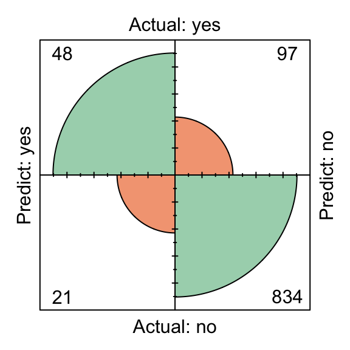

```r
conf.mat(predict_knn, test_labels)
  Setting levels: reference = "yes", case = "no"
        Predict
  Actual yes  no
     yes  48  97
     no   21 834

conf.mat.plot(predict_knn, test_labels)
  Setting levels: reference = "yes", case = "no"
```

To report Mean Squared Error (MSE):

```r
mse(predict_knn, test_labels)
  [1] 0.118
```

# Classification by kNN algorithm with data transformation

The predictors that we used in the previous part, do not have the same scale. For example, variable `day_mins` change between 0 and 351.5, whereas variable `voice_plan` is binary. In this case, the values of variable `day_mins` will overwhelm the contribution of `voice_plan`. To avoid this situation we use normalization. So, we use min-max normalization and transfer the predictors as follows:

```r
predict_knn_trans = kNN(formula, train = train_set, test = test_set, k = 6, scaler = "minmax")
```

To report Confusion Matrix:

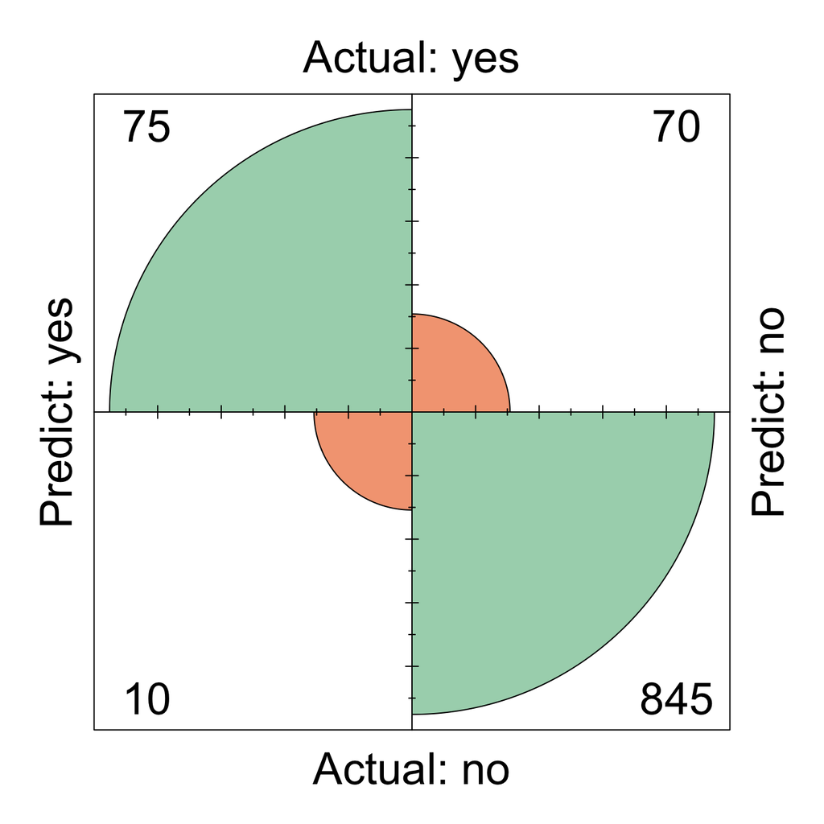

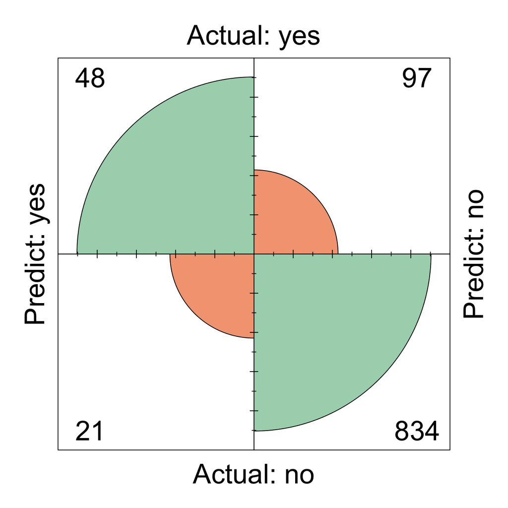

```r
conf.mat.plot(predict_knn_trans, test_labels)
  Setting levels: reference = "yes", case = "no"

conf.mat.plot(predict_knn, test_labels)
  Setting levels: reference = "yes", case = "no"
```

To report the ROC curve, we need the probability of our classification prediction. We can have it by using:

```r
prob_knn = kNN(formula, train = train_set, test = test_set, k = 6, type = "prob")[, 1]

prob_knn_trans = kNN(formula, train = train_set, test = test_set, scaler = "minmax", k = 6, type = "prob")[, 1]
```

To visualize the model performance between the raw data and the transformed data, we could report the ROC curve plot as well as AUC (Area Under the Curve) by using the `plot.roc` function from the **pROC** package:

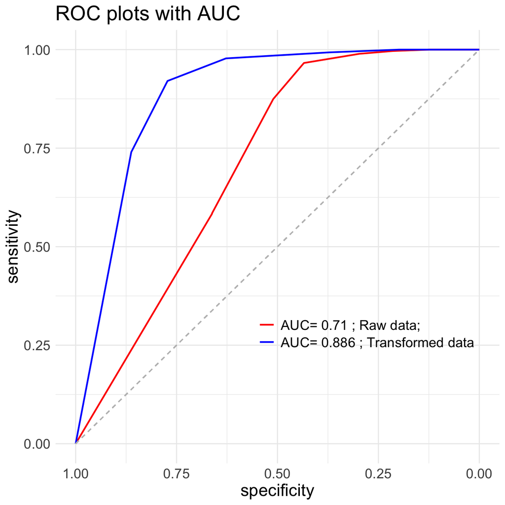

```r
roc_knn = roc(test_labels, prob_knn)
roc_knn_trans = roc(test_labels, prob_knn_trans)

ggroc(list(roc_knn, roc_knn_trans), linewidth = 0.8) +
    theme_minimal() + ggtitle("ROC plots with AUC") +
  scale_color_manual(values = c("red", "blue"),
    labels = c(paste("AUC=", round(auc(roc_knn), 3), "; Raw data; "),
                paste("AUC=", round(auc(roc_knn_trans), 3), "; Transformed data"))) +
  theme(legend.title = element_blank()) +
  theme(legend.position = c(.7, .3), text = element_text(size = 17)) +
    geom_segment(aes(x = 1, xend = 0, y = 0, yend = 1), color = "grey", linetype = "dashed")
```

# Optimal value of k for the kNN algorithm

To find out the optimal value of `k` based on *Accuracy*, for the different values of k from 1 to 30, we run the k-nearest neighbor for the test set and compute the *Accuracy* for these models, by running `kNN.plot()` command

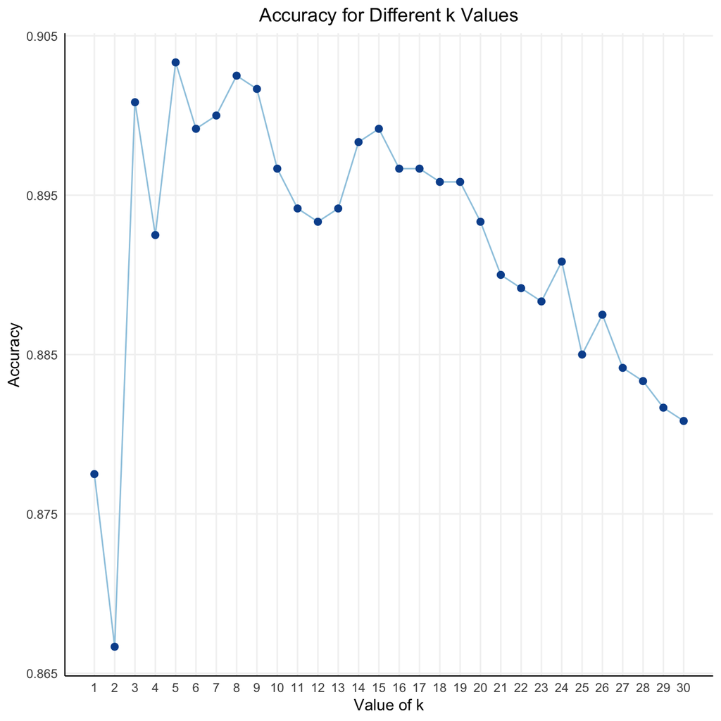

```r
kNN.plot(formula, train = train_set, ratio = c(0.7, 0.3), scaler = "minmax",
          k.max = 30, set.seed = 3)
  Setting levels: reference = "yes", case = "no"
```